# Risk Factor Analysis

## Outcome Variable

**Outcome Variable:** wasted

## Predictor Variables

**Intervention Variable:** brthmon

**Adjustment Set:**

unadjusted

## Stratifying Variables

The analysis was stratified on these variable(s):

- agecat
- studyid
- country

## Data Summary

| agecat | studyid | country | brthmon | wasted | n_cell | n |
| --- | --- | --- | --- | --- | --- | --- |
| Birth | ki0047075b-MAL-ED | BANGLADESH | 1 | 0 | 18 | 241 |
| Birth | ki0047075b-MAL-ED | BANGLADESH | 1 | 1 | 1 | 241 |
| Birth | ki0047075b-MAL-ED | BANGLADESH | 2 | 0 | 18 | 241 |
| Birth | ki0047075b-MAL-ED | BANGLADESH | 2 | 1 | 5 | 241 |
| Birth | ki0047075b-MAL-ED | BANGLADESH | 3 | 0 | 18 | 241 |
| Birth | ki0047075b-MAL-ED | BANGLADESH | 3 | 1 | 4 | 241 |
| Birth | ki0047075b-MAL-ED | BANGLADESH | 4 | 0 | 17 | 241 |
| Birth | ki0047075b-MAL-ED | BANGLADESH | 4 | 1 | 4 | 241 |
| Birth | ki0047075b-MAL-ED | BANGLADESH | 5 | 0 | 18 | 241 |
| Birth | ki0047075b-MAL-ED | BANGLADESH | 5 | 1 | 2 | 241 |
| Birth | ki0047075b-MAL-ED | BANGLADESH | 6 | 0 | 10 | 241 |
| Birth | ki0047075b-MAL-ED | BANGLADESH | 6 | 1 | 0 | 241 |
| Birth | ki0047075b-MAL-ED | BANGLADESH | 7 | 0 | 14 | 241 |
| Birth | ki0047075b-MAL-ED | BANGLADESH | 7 | 1 | 5 | 241 |
| Birth | ki0047075b-MAL-ED | BANGLADESH | 8 | 0 | 20 | 241 |
| Birth | ki0047075b-MAL-ED | BANGLADESH | 8 | 1 | 3 | 241 |
| Birth | ki0047075b-MAL-ED | BANGLADESH | 9 | 0 | 12 | 241 |
| Birth | ki0047075b-MAL-ED | BANGLADESH | 9 | 1 | 7 | 241 |
| Birth | ki0047075b-MAL-ED | BANGLADESH | 10 | 0 | 21 | 241 |
| Birth | ki0047075b-MAL-ED | BANGLADESH | 10 | 1 | 3 | 241 |
| Birth | ki0047075b-MAL-ED | BANGLADESH | 11 | 0 | 13 | 241 |
| Birth | ki0047075b-MAL-ED | BANGLADESH | 11 | 1 | 2 | 241 |
| Birth | ki0047075b-MAL-ED | BANGLADESH | 12 | 0 | 22 | 241 |
| Birth | ki0047075b-MAL-ED | BANGLADESH | 12 | 1 | 4 | 241 |
| Birth | ki0047075b-MAL-ED | BRAZIL | 1 | 0 | 8 | 183 |
| Birth | ki0047075b-MAL-ED | BRAZIL | 1 | 1 | 2 | 183 |
| Birth | ki0047075b-MAL-ED | BRAZIL | 2 | 0 | 17 | 183 |
| Birth | ki0047075b-MAL-ED | BRAZIL | 2 | 1 | 1 | 183 |
| Birth | ki0047075b-MAL-ED | BRAZIL | 3 | 0 | 17 | 183 |
| Birth | ki0047075b-MAL-ED | BRAZIL | 3 | 1 | 0 | 183 |

[output cut: 1698 more lines]

The following strata were considered:

- agecat: 24 months, studyid: ki0047075b-MAL-ED, country: BANGLADESH
- agecat: 24 months, studyid: ki0047075b-MAL-ED, country: BRAZIL
- agecat: 24 months, studyid: ki0047075b-MAL-ED, country: INDIA
- agecat: 24 months, studyid: ki0047075b-MAL-ED, country: NEPAL
- agecat: 24 months, studyid: ki0047075b-MAL-ED, country: PERU
- agecat: 24 months, studyid: ki0047075b-MAL-ED, country: SOUTH AFRICA
- agecat: 24 months, studyid: ki0047075b-MAL-ED, country: TANZANIA, UNITED REPUBLIC OF
- agecat: 24 months, studyid: ki1000108-CMC-V-BCS-2002, country: INDIA
- agecat: 24 months, studyid: ki1000108-IRC, country: INDIA
- agecat: 24 months, studyid: ki1017093-NIH-Birth, country: BANGLADESH
- agecat: 24 months, studyid: ki1066203-TanzaniaChild2, country: TANZANIA, UNITED REPUBLIC OF
- agecat: 24 months, studyid: ki1101329-Keneba, country: GAMBIA
- agecat: 24 months, studyid: ki1113344-GMS-Nepal, country: NEPAL
- agecat: 24 months, studyid: ki1114097-CMIN, country: BANGLADESH
- agecat: 24 months, studyid: ki1114097-CMIN, country: GUINEA-BISSAU
- agecat: 24 months, studyid: ki1114097-CMIN, country: PERU
- agecat: 24 months, studyid: ki1114097-CONTENT, country: PERU
- agecat: 24 months, studyid: ki1119695-PROBIT, country: BELARUS
- agecat: 24 months, studyid: ki1126311-ZVITAMBO, country: ZIMBABWE
- agecat: 24 months, studyid: ki1148112-LCNI-5, country: MALAWI
- agecat: 24 months, studyid: kiGH5241-JiVitA-3, country: BANGLADESH
- agecat: 24 months, studyid: kiGH5241-JiVitA-4, country: BANGLADESH
- agecat: 6 months, studyid: ki0047075b-MAL-ED, country: BANGLADESH
- agecat: 6 months, studyid: ki0047075b-MAL-ED, country: BRAZIL
- agecat: 6 months, studyid: ki0047075b-MAL-ED, country: INDIA
- agecat: 6 months, studyid: ki0047075b-MAL-ED, country: NEPAL
- agecat: 6 months, studyid: ki0047075b-MAL-ED, country: PERU
- agecat: 6 months, studyid: ki0047075b-MAL-ED, country: SOUTH AFRICA
- agecat: 6 months, studyid: ki0047075b-MAL-ED, country: TANZANIA, UNITED REPUBLIC OF
- agecat: 6 months, studyid: ki1000108-CMC-V-BCS-2002, country: INDIA
- agecat: 6 months, studyid: ki1000108-IRC, country: INDIA
- agecat: 6 months, studyid: ki1000109-EE, country: PAKISTAN
- agecat: 6 months, studyid: ki1000109-ResPak, country: PAKISTAN
- agecat: 6 months, studyid: ki1000304b-SAS-CompFeed, country: INDIA
- agecat: 6 months, studyid: ki1000304b-SAS-FoodSuppl, country: INDIA
- agecat: 6 months, studyid: ki1017093-NIH-Birth, country: BANGLADESH
- agecat: 6 months, studyid: ki1066203-TanzaniaChild2, country: TANZANIA, UNITED REPUBLIC OF
- agecat: 6 months, studyid: ki1101329-Keneba, country: GAMBIA
- agecat: 6 months, studyid: ki1112895-Guatemala BSC, country: GUATEMALA
- agecat: 6 months, studyid: ki1113344-GMS-Nepal, country: NEPAL
- agecat: 6 months, studyid: ki1114097-CMIN, country: BANGLADESH
- agecat: 6 months, studyid: ki1114097-CMIN, country: BRAZIL
- agecat: 6 months, studyid: ki1114097-CMIN, country: GUINEA-BISSAU
- agecat: 6 months, studyid: ki1114097-CMIN, country: PERU
- agecat: 6 months, studyid: ki1114097-CONTENT, country: PERU
- agecat: 6 months, studyid: ki1119695-PROBIT, country: BELARUS
- agecat: 6 months, studyid: ki1126311-ZVITAMBO, country: ZIMBABWE
- agecat: 6 months, studyid: ki1148112-LCNI-5, country: MALAWI
- agecat: 6 months, studyid: kiGH5241-JiVitA-3, country: BANGLADESH
- agecat: 6 months, studyid: kiGH5241-JiVitA-4, country: BANGLADESH
- agecat: Birth, studyid: ki0047075b-MAL-ED, country: BANGLADESH
- agecat: Birth, studyid: ki0047075b-MAL-ED, country: BRAZIL
- agecat: Birth, studyid: ki0047075b-MAL-ED, country: INDIA
- agecat: Birth, studyid: ki0047075b-MAL-ED, country: NEPAL
- agecat: Birth, studyid: ki0047075b-MAL-ED, country: PERU
- agecat: Birth, studyid: ki0047075b-MAL-ED, country: SOUTH AFRICA
- agecat: Birth, studyid: ki0047075b-MAL-ED, country: TANZANIA, UNITED REPUBLIC OF
- agecat: Birth, studyid: ki1000108-CMC-V-BCS-2002, country: INDIA
- agecat: Birth, studyid: ki1000108-IRC, country: INDIA
- agecat: Birth, studyid: ki1000109-EE, country: PAKISTAN
- agecat: Birth, studyid: ki1000109-ResPak, country: PAKISTAN
- agecat: Birth, studyid: ki1000304b-SAS-CompFeed, country: INDIA
- agecat: Birth, studyid: ki1017093-NIH-Birth, country: BANGLADESH
- agecat: Birth, studyid: ki1101329-Keneba, country: GAMBIA
- agecat: Birth, studyid: ki1114097-CMIN, country: BANGLADESH
- agecat: Birth, studyid: ki1114097-CMIN, country: BRAZIL
- agecat: Birth, studyid: ki1114097-CMIN, country: PERU
- agecat: Birth, studyid: ki1114097-CONTENT, country: PERU
- agecat: Birth, studyid: ki1119695-PROBIT, country: BELARUS
- agecat: Birth, studyid: ki1126311-ZVITAMBO, country: ZIMBABWE
- agecat: Birth, studyid: kiGH5241-JiVitA-3, country: BANGLADESH
- agecat: Birth, studyid: kiGH5241-JiVitA-4, country: BANGLADESH

### Dropped Strata

Some strata were dropped due to rare outcomes:

- agecat: Birth, studyid: ki0047075b-MAL-ED, country: BANGLADESH
- agecat: Birth, studyid: ki0047075b-MAL-ED, country: BRAZIL
- agecat: Birth, studyid: ki0047075b-MAL-ED, country: INDIA
- agecat: Birth, studyid: ki0047075b-MAL-ED, country: NEPAL
- agecat: Birth, studyid: ki0047075b-MAL-ED, country: PERU
- agecat: Birth, studyid: ki0047075b-MAL-ED, country: SOUTH AFRICA
- agecat: Birth, studyid: ki0047075b-MAL-ED, country: TANZANIA, UNITED REPUBLIC OF
- agecat: Birth, studyid: ki1000108-CMC-V-BCS-2002, country: INDIA
- agecat: Birth, studyid: ki1000108-IRC, country: INDIA
- agecat: Birth, studyid: ki1000109-EE, country: PAKISTAN
- agecat: Birth, studyid: ki1000109-ResPak, country: PAKISTAN
- agecat: Birth, studyid: ki1000304b-SAS-CompFeed, country: INDIA
- agecat: Birth, studyid: ki1017093-NIH-Birth, country: BANGLADESH
- agecat: Birth, studyid: ki1101329-Keneba, country: GAMBIA
- agecat: Birth, studyid: ki1114097-CMIN, country: BANGLADESH
- agecat: Birth, studyid: ki1114097-CMIN, country: BRAZIL
- agecat: Birth, studyid: ki1114097-CMIN, country: PERU
- agecat: Birth, studyid: ki1114097-CONTENT, country: PERU
- agecat: Birth, studyid: kiGH5241-JiVitA-4, country: BANGLADESH
- agecat: 6 months, studyid: ki0047075b-MAL-ED, country: BANGLADESH
- agecat: 6 months, studyid: ki0047075b-MAL-ED, country: BRAZIL
- agecat: 6 months, studyid: ki0047075b-MAL-ED, country: INDIA
- agecat: 6 months, studyid: ki0047075b-MAL-ED, country: NEPAL
- agecat: 6 months, studyid: ki0047075b-MAL-ED, country: PERU
- agecat: 6 months, studyid: ki0047075b-MAL-ED, country: SOUTH AFRICA
- agecat: 6 months, studyid: ki0047075b-MAL-ED, country: TANZANIA, UNITED REPUBLIC OF
- agecat: 6 months, studyid: ki1000108-CMC-V-BCS-2002, country: INDIA
- agecat: 6 months, studyid: ki1000108-IRC, country: INDIA
- agecat: 6 months, studyid: ki1000109-EE, country: PAKISTAN
- agecat: 6 months, studyid: ki1000109-ResPak, country: PAKISTAN
- agecat: 6 months, studyid: ki1000304b-SAS-CompFeed, country: INDIA
- agecat: 6 months, studyid: ki1000304b-SAS-FoodSuppl, country: INDIA
- agecat: 6 months, studyid: ki1017093-NIH-Birth, country: BANGLADESH
- agecat: 6 months, studyid: ki1066203-TanzaniaChild2, country: TANZANIA, UNITED REPUBLIC OF
- agecat: 6 months, studyid: ki1112895-Guatemala BSC, country: GUATEMALA
- agecat: 6 months, studyid: ki1113344-GMS-Nepal, country: NEPAL
- agecat: 6 months, studyid: ki1114097-CMIN, country: BANGLADESH
- agecat: 6 months, studyid: ki1114097-CMIN, country: BRAZIL
- agecat: 6 months, studyid: ki1114097-CMIN, country: GUINEA-BISSAU
- agecat: 6 months, studyid: ki1114097-CMIN, country: PERU
- agecat: 6 months, studyid: ki1114097-CONTENT, country: PERU
- agecat: 6 months, studyid: ki1148112-LCNI-5, country: MALAWI
- agecat: 6 months, studyid: kiGH5241-JiVitA-4, country: BANGLADESH
- agecat: 24 months, studyid: ki0047075b-MAL-ED, country: BANGLADESH
- agecat: 24 months, studyid: ki0047075b-MAL-ED, country: BRAZIL
- agecat: 24 months, studyid: ki0047075b-MAL-ED, country: INDIA
- agecat: 24 months, studyid: ki0047075b-MAL-ED, country: NEPAL
- agecat: 24 months, studyid: ki0047075b-MAL-ED, country: PERU
- agecat: 24 months, studyid: ki0047075b-MAL-ED, country: SOUTH AFRICA
- agecat: 24 months, studyid: ki0047075b-MAL-ED, country: TANZANIA, UNITED REPUBLIC OF
- agecat: 24 months, studyid: ki1000108-CMC-V-BCS-2002, country: INDIA
- agecat: 24 months, studyid: ki1000108-IRC, country: INDIA
- agecat: 24 months, studyid: ki1017093-NIH-Birth, country: BANGLADESH
- agecat: 24 months, studyid: ki1066203-TanzaniaChild2, country: TANZANIA, UNITED REPUBLIC OF
- agecat: 24 months, studyid: ki1113344-GMS-Nepal, country: NEPAL
- agecat: 24 months, studyid: ki1114097-CMIN, country: BANGLADESH
- agecat: 24 months, studyid: ki1114097-CMIN, country: GUINEA-BISSAU
- agecat: 24 months, studyid: ki1114097-CMIN, country: PERU
- agecat: 24 months, studyid: ki1114097-CONTENT, country: PERU
- agecat: 24 months, studyid: ki1119695-PROBIT, country: BELARUS
- agecat: 24 months, studyid: ki1126311-ZVITAMBO, country: ZIMBABWE
- agecat: 24 months, studyid: ki1148112-LCNI-5, country: MALAWI
- agecat: 24 months, studyid: kiGH5241-JiVitA-4, country: BANGLADESH

## Methods Detail

We’re interested in the causal parameters $E[Y_a]$ for all values of $a \in \mathcal{A}$. These parameters represent the mean outcome if, possibly contrary to fact, we intervened to set all units to have $A=a$. Under the randomization and positivity assumptions, these are identified by the statistical parameters $\psi_a=E_W[E_{Y|A,W}(Y|A=a,W)]$. In addition, we’re interested in the mean of $Y$, $E[Y]$ under no intervention (the observed mean). We will estimate these parameters by using SuperLearner to fit the relevant likelihood factors – $E_{Y|A,W}(Y|A=a,W)$ and $p(A=a|W)$, and then updating our likelihood fit using a joint TMLE.

For unadjusted analyses ($W=\{\}$), initial likelihoods were estimated using Lrnr_glm to estimate the simple $E(Y|A)$ and Lrnr_mean to estimate $p(A)$. For adjusted analyses, a small library containing Lrnr_glmnet, Lrnr_xgboost, and Lrnr_mean was used.

Having estimated these parameters, we will then use the delta method to estimate relative risks and attributable risks relative to a prespecified baseline level of $A$.

# Results Detail

## Results Plots

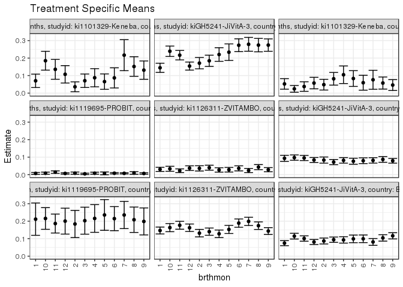

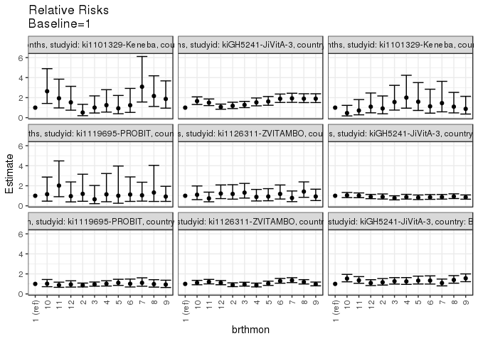

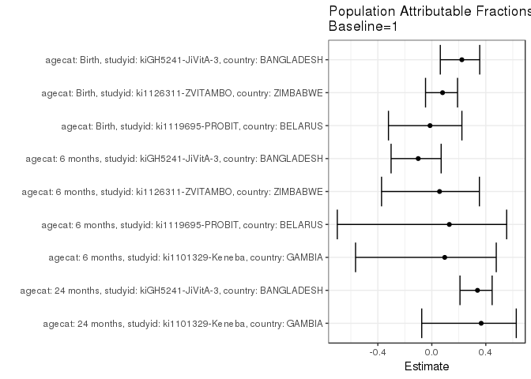

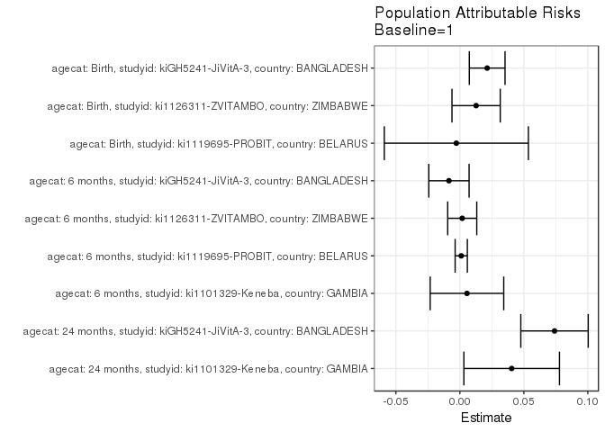

## Results Table

### Parameter: TSM

| agecat | studyid | country | intervention_level | baseline_level | estimate | ci_lower | ci_upper |
| --- | --- | --- | --- | --- | --- | --- | --- |
| Birth | ki1119695-PROBIT | BELARUS | 1 | NA | 0.2116788 | 0.1193161 | 0.3040416 |
| Birth | ki1119695-PROBIT | BELARUS | 2 | NA | 0.1839800 | 0.1064045 | 0.2615554 |
| Birth | ki1119695-PROBIT | BELARUS | 3 | NA | 0.2029756 | 0.1258272 | 0.2801239 |
| Birth | ki1119695-PROBIT | BELARUS | 4 | NA | 0.2156863 | 0.1364110 | 0.2949615 |
| Birth | ki1119695-PROBIT | BELARUS | 5 | NA | 0.2356688 | 0.1478587 | 0.3234789 |
| Birth | ki1119695-PROBIT | BELARUS | 6 | NA | 0.2147059 | 0.1458375 | 0.2835742 |
| Birth | ki1119695-PROBIT | BELARUS | 7 | NA | 0.2354312 | 0.1577090 | 0.3131535 |
| Birth | ki1119695-PROBIT | BELARUS | 8 | NA | 0.2082695 | 0.1357276 | 0.2808114 |
| Birth | ki1119695-PROBIT | BELARUS | 9 | NA | 0.1986405 | 0.1215408 | 0.2757402 |
| Birth | ki1119695-PROBIT | BELARUS | 10 | NA | 0.2155809 | 0.1536363 | 0.2775256 |
| Birth | ki1119695-PROBIT | BELARUS | 11 | NA | 0.1865510 | 0.1324606 | 0.2406414 |
| Birth | ki1119695-PROBIT | BELARUS | 12 | NA | 0.2003891 | 0.1263248 | 0.2744534 |
| Birth | ki1126311-ZVITAMBO | ZIMBABWE | 1 | NA | 0.1467964 | 0.1270419 | 0.1665510 |
| Birth | ki1126311-ZVITAMBO | ZIMBABWE | 2 | NA | 0.1316614 | 0.1102383 | 0.1530846 |
| Birth | ki1126311-ZVITAMBO | ZIMBABWE | 3 | NA | 0.1402043 | 0.1194678 | 0.1609408 |
| Birth | ki1126311-ZVITAMBO | ZIMBABWE | 4 | NA | 0.1279826 | 0.1064182 | 0.1495471 |
| Birth | ki1126311-ZVITAMBO | ZIMBABWE | 5 | NA | 0.1528525 | 0.1297120 | 0.1759930 |
| Birth | ki1126311-ZVITAMBO | ZIMBABWE | 6 | NA | 0.1889313 | 0.1652304 | 0.2126322 |
| Birth | ki1126311-ZVITAMBO | ZIMBABWE | 7 | NA | 0.1989051 | 0.1752718 | 0.2225384 |
| Birth | ki1126311-ZVITAMBO | ZIMBABWE | 8 | NA | 0.1743892 | 0.1528025 | 0.1959760 |
| Birth | ki1126311-ZVITAMBO | ZIMBABWE | 9 | NA | 0.1436597 | 0.1241839 | 0.1631356 |
| Birth | ki1126311-ZVITAMBO | ZIMBABWE | 10 | NA | 0.1632653 | 0.1401237 | 0.1864069 |
| Birth | ki1126311-ZVITAMBO | ZIMBABWE | 11 | NA | 0.1767906 | 0.1542761 | 0.1993050 |
| Birth | ki1126311-ZVITAMBO | ZIMBABWE | 12 | NA | 0.1625659 | 0.1411279 | 0.1840039 |
| Birth | kiGH5241-JiVitA-3 | BANGLADESH | 1 | NA | 0.0745342 | 0.0600178 | 0.0890505 |
| Birth | kiGH5241-JiVitA-3 | BANGLADESH | 2 | NA | 0.0867866 | 0.0698756 | 0.1036975 |
| Birth | kiGH5241-JiVitA-3 | BANGLADESH | 3 | NA | 0.0942912 | 0.0790919 | 0.1094905 |
| Birth | kiGH5241-JiVitA-3 | BANGLADESH | 4 | NA | 0.0930027 | 0.0747962 | 0.1112092 |
| Birth | kiGH5241-JiVitA-3 | BANGLADESH | 5 | NA | 0.0989717 | 0.0771798 | 0.1207636 |
| Birth | kiGH5241-JiVitA-3 | BANGLADESH | 6 | NA | 0.0993939 | 0.0776133 | 0.1211745 |

[output cut: 78 more lines]

### Parameter: E(Y)

| agecat | studyid | country | intervention_level | baseline_level | estimate | ci_lower | ci_upper |
| --- | --- | --- | --- | --- | --- | --- | --- |
| Birth | ki1119695-PROBIT | BELARUS | NA | NA | 0.2089120 | 0.1435514 | 0.2742726 |
| Birth | ki1126311-ZVITAMBO | ZIMBABWE | NA | NA | 0.1594921 | 0.1531776 | 0.1658066 |
| Birth | kiGH5241-JiVitA-3 | BANGLADESH | NA | NA | 0.0958686 | 0.0906699 | 0.1010673 |
| 6 months | ki1101329-Keneba | GAMBIA | NA | NA | 0.0579225 | 0.0479029 | 0.0679420 |
| 6 months | ki1119695-PROBIT | BELARUS | NA | NA | 0.0082503 | 0.0066012 | 0.0098994 |
| 6 months | ki1126311-ZVITAMBO | ZIMBABWE | NA | NA | 0.0320668 | 0.0282681 | 0.0358654 |
| 6 months | kiGH5241-JiVitA-3 | BANGLADESH | NA | NA | 0.0847478 | 0.0799486 | 0.0895469 |
| 24 months | ki1101329-Keneba | GAMBIA | NA | NA | 0.1106605 | 0.0958563 | 0.1254646 |
| 24 months | kiGH5241-JiVitA-3 | BANGLADESH | NA | NA | 0.2185461 | 0.2086586 | 0.2284336 |

### Parameter: RR

| agecat | studyid | country | intervention_level | baseline_level | estimate | ci_lower | ci_upper |
| --- | --- | --- | --- | --- | --- | --- | --- |
| Birth | ki1119695-PROBIT | BELARUS | 1 | 1 | 1.0000000 | 1.0000000 | 1.0000000 |
| Birth | ki1119695-PROBIT | BELARUS | 2 | 1 | 0.8691468 | 0.6971061 | 1.0836459 |
| Birth | ki1119695-PROBIT | BELARUS | 3 | 1 | 0.9588845 | 0.7740358 | 1.1878773 |
| Birth | ki1119695-PROBIT | BELARUS | 4 | 1 | 1.0189317 | 0.7883067 | 1.3170277 |
| Birth | ki1119695-PROBIT | BELARUS | 5 | 1 | 1.1133319 | 0.8484102 | 1.4609771 |
| Birth | ki1119695-PROBIT | BELARUS | 6 | 1 | 1.0143002 | 0.6937721 | 1.4829149 |
| Birth | ki1119695-PROBIT | BELARUS | 7 | 1 | 1.1122096 | 0.7692278 | 1.6081195 |
| Birth | ki1119695-PROBIT | BELARUS | 8 | 1 | 0.9838940 | 0.6815042 | 1.4204569 |
| Birth | ki1119695-PROBIT | BELARUS | 9 | 1 | 0.9384050 | 0.6438065 | 1.3678086 |
| Birth | ki1119695-PROBIT | BELARUS | 10 | 1 | 1.0184340 | 0.7199634 | 1.4406397 |
| Birth | ki1119695-PROBIT | BELARUS | 11 | 1 | 0.8812925 | 0.6606283 | 1.1756635 |
| Birth | ki1119695-PROBIT | BELARUS | 12 | 1 | 0.9466658 | 0.6827432 | 1.3126108 |
| Birth | ki1126311-ZVITAMBO | ZIMBABWE | 1 | 1 | 1.0000000 | 1.0000000 | 1.0000000 |
| Birth | ki1126311-ZVITAMBO | ZIMBABWE | 2 | 1 | 0.8968981 | 0.7261745 | 1.1077589 |
| Birth | ki1126311-ZVITAMBO | ZIMBABWE | 3 | 1 | 0.9550932 | 0.7819947 | 1.1665079 |
| Birth | ki1126311-ZVITAMBO | ZIMBABWE | 4 | 1 | 0.8718376 | 0.7027244 | 1.0816484 |
| Birth | ki1126311-ZVITAMBO | ZIMBABWE | 5 | 1 | 1.0412551 | 0.8503319 | 1.2750458 |
| Birth | ki1126311-ZVITAMBO | ZIMBABWE | 6 | 1 | 1.2870292 | 1.0707536 | 1.5469892 |
| Birth | ki1126311-ZVITAMBO | ZIMBABWE | 7 | 1 | 1.3549724 | 1.1323132 | 1.6214155 |
| Birth | ki1126311-ZVITAMBO | ZIMBABWE | 8 | 1 | 1.1879663 | 0.9894545 | 1.4263051 |
| Birth | ki1126311-ZVITAMBO | ZIMBABWE | 9 | 1 | 0.9786322 | 0.8084642 | 1.1846177 |
| Birth | ki1126311-ZVITAMBO | ZIMBABWE | 10 | 1 | 1.1121885 | 0.9147367 | 1.3522616 |
| Birth | ki1126311-ZVITAMBO | ZIMBABWE | 11 | 1 | 1.2043247 | 1.0006419 | 1.4494677 |
| Birth | ki1126311-ZVITAMBO | ZIMBABWE | 12 | 1 | 1.1074241 | 0.9172483 | 1.3370297 |
| Birth | kiGH5241-JiVitA-3 | BANGLADESH | 1 | 1 | 1.0000000 | 1.0000000 | 1.0000000 |
| Birth | kiGH5241-JiVitA-3 | BANGLADESH | 2 | 1 | 1.1643862 | 0.8842677 | 1.5332408 |
| Birth | kiGH5241-JiVitA-3 | BANGLADESH | 3 | 1 | 1.2650738 | 0.9840190 | 1.6264032 |
| Birth | kiGH5241-JiVitA-3 | BANGLADESH | 4 | 1 | 1.2477857 | 0.9536854 | 1.6325813 |
| Birth | kiGH5241-JiVitA-3 | BANGLADESH | 5 | 1 | 1.3278706 | 0.9932015 | 1.7753099 |
| Birth | kiGH5241-JiVitA-3 | BANGLADESH | 6 | 1 | 1.3335354 | 0.9872364 | 1.8013078 |

[output cut: 78 more lines]

### Parameter: PAR

| agecat | studyid | country | intervention_level | baseline_level | estimate | ci_lower | ci_upper |
| --- | --- | --- | --- | --- | --- | --- | --- |
| Birth | ki1119695-PROBIT | BELARUS | 1 | NA | -0.0027668 | -0.0590660 | 0.0535324 |
| Birth | ki1126311-ZVITAMBO | ZIMBABWE | 1 | NA | 0.0126957 | -0.0061619 | 0.0315533 |
| Birth | kiGH5241-JiVitA-3 | BANGLADESH | 1 | NA | 0.0213344 | 0.0073775 | 0.0352914 |
| 6 months | ki1101329-Keneba | GAMBIA | 1 | NA | 0.0055415 | -0.0232019 | 0.0342848 |
| 6 months | ki1119695-PROBIT | BELARUS | 1 | NA | 0.0010708 | -0.0036980 | 0.0058396 |
| 6 months | ki1126311-ZVITAMBO | ZIMBABWE | 1 | NA | 0.0018401 | -0.0095182 | 0.0131984 |
| 6 months | kiGH5241-JiVitA-3 | BANGLADESH | 1 | NA | -0.0085358 | -0.0242746 | 0.0072030 |
| 24 months | ki1101329-Keneba | GAMBIA | 1 | NA | 0.0404850 | 0.0031322 | 0.0778379 |
| 24 months | kiGH5241-JiVitA-3 | BANGLADESH | 1 | NA | 0.0739678 | 0.0476224 | 0.1003132 |

### Parameter: PAF

| agecat | studyid | country | intervention_level | baseline_level | estimate | ci_lower | ci_upper |
| --- | --- | --- | --- | --- | --- | --- | --- |
| Birth | ki1119695-PROBIT | BELARUS | 1 | NA | -0.0132438 | -0.3212098 | 0.2229371 |
| Birth | ki1126311-ZVITAMBO | ZIMBABWE | 1 | NA | 0.0796006 | -0.0465338 | 0.1905326 |
| Birth | kiGH5241-JiVitA-3 | BANGLADESH | 1 | NA | 0.2225384 | 0.0629423 | 0.3549528 |
| 6 months | ki1101329-Keneba | GAMBIA | 1 | NA | 0.0956710 | -0.5650275 | 0.4774463 |
| 6 months | ki1119695-PROBIT | BELARUS | 1 | NA | 0.1297909 | -0.7003385 | 0.5546394 |
| 6 months | ki1126311-ZVITAMBO | ZIMBABWE | 1 | NA | 0.0573832 | -0.3724683 | 0.3526070 |
| 6 months | kiGH5241-JiVitA-3 | BANGLADESH | 1 | NA | -0.1007200 | -0.3017247 | 0.0692467 |
| 24 months | ki1101329-Keneba | GAMBIA | 1 | NA | 0.3658492 | -0.0747368 | 0.6258179 |
| 24 months | kiGH5241-JiVitA-3 | BANGLADESH | 1 | NA | 0.3384540 | 0.2087415 | 0.4469026 |